# Random Forest and Ensembles

```python
import numpy as np
import matplotlib.pyplot as plt

from IPython.display import Image
from IPython.display import SVG
```

```python
from sklearn.tree import DecisionTreeClassifier
```

## Ensembles

https://en.wikipedia.org/wiki/Ensemble_learning  
bishop chapter 14

- What is ensembling?

In statistics and machine learning, ensemble methods use multiple learning algorithms to obtain better predictive performance than could be obtained from any of the constituent learning algorithms alone.

- Max Voting
- Averaging
- Weighted Averaging
- bagging
- stacking
- blending

## Bagging (bishop 14.2)

- What is bootstrap aggregation(bagging)?
- Derrivations

Bootstrap aggregating, often abbreviated as bagging, involves having each model in the ensemble vote with equal weight. In order to promote model variance, bagging trains each model in the ensemble using a randomly drawn subset of the training set. As an example, the random forest algorithm combines random decision trees with bagging to achieve very high classification accuracy

```python
SVG(filename='Ensemble_Bagging.svg')
```

[figure not shown]

1. Random subsets are created from the original dataset (bootstrapping).
2. At each node in the decision tree, only a random set of features are considered to decide the best split.
3. A decision tree model is fitted on each of the subsets.
4. The final prediction is calculated by averaging the predictions from all decision trees.

Advantages

Bagging takes the advantage of ensemble learning wherein multiple weak learner outperform a single strong learner. It helps reduce variance and thus helps us avoid overfitting.

Disadvantages

There is loss of interpretability of the model. There can possibly be a problem of high bias if not modeled properly. Another important disadvantage is that while bagging gives us more accuracy, it is computationally expensive and may not be desirable depending on the use case.

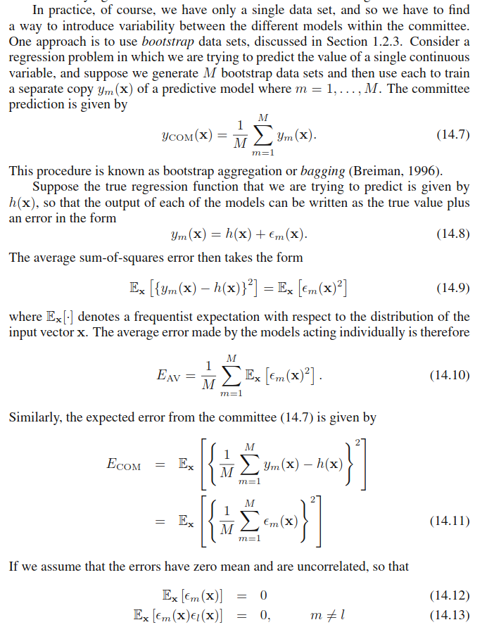

```python
Image(filename='Screenshot_20200529_193028.png')
```

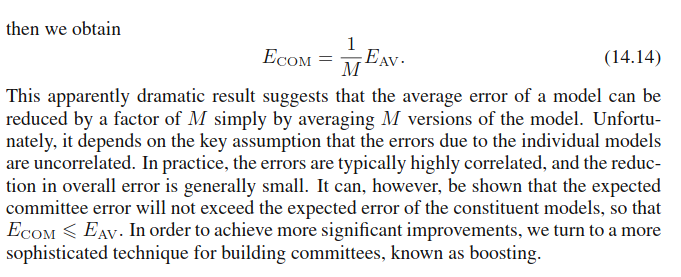

```python
Image(filename='Screenshot_20200529_193049.png')
```

There are many bagging algorithms of which perhaps the most prominent would be Random Forest. I’d hopefully be writing a blog about it in the future.

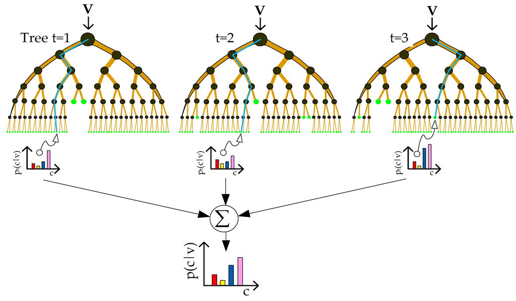

```python
Image(filename='9.png')
```

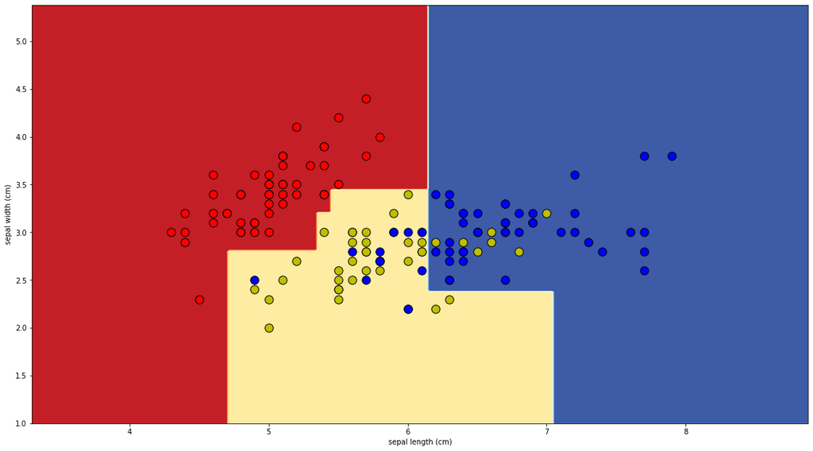

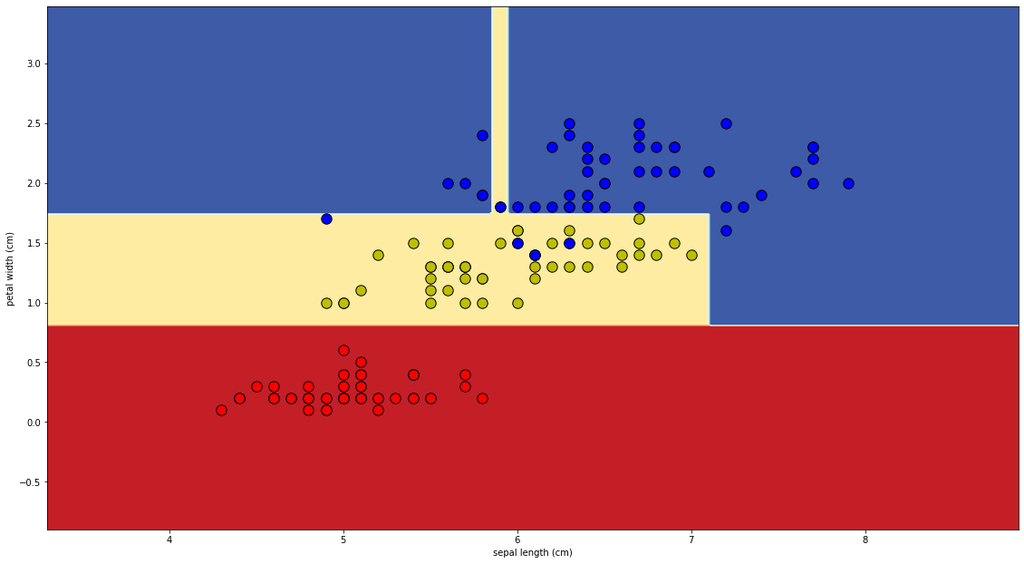

```python
import numpy as np
import matplotlib.pyplot as plt
import matplotlib
from sklearn.datasets import load_iris
from sklearn.tree import DecisionTreeClassifier
from sklearn.ensemble import RandomForestClassifier

iris = load_iris()
for pairidx, pair in enumerate([[0, 1],[0, 3]]):
    X = iris.data[:, pair]
    y = iris.target

    clf = DecisionTreeClassifier(criterion="gini", max_depth=4).fit(X, y)

    plt.figure(figsize=(16,9))
    plt.subplot()
    x_min, x_max = X[:, 0].min() - 1, X[:, 0].max() + 1
    y_min, y_max = X[:, 1].min() - 1, X[:, 1].max() + 1
    xx, yy = np.meshgrid(np.arange(x_min, x_max, 0.02),
                     np.arange(y_min, y_max, 0.02))
    plt.tight_layout(h_pad=0.5, w_pad=0.5, pad=2.5)

    Z = clf.predict(np.c_[xx.ravel(), yy.ravel()])
    Z = Z.reshape(xx.shape)

    cs = plt.contourf(xx, yy, Z, cmap=plt.cm.RdYlBu)
    plt.xlabel(iris.feature_names[pair[0]])
    plt.ylabel(iris.feature_names[pair[1]])

    for i, color in zip(range(3), "ryb"):
        idx = np.where(y == i)
        plt.scatter(X[idx, 0], X[idx, 1], c=color, label=iris.target_names[i],
                    cmap=plt.cm.RdYlBu, edgecolor='black', s=130)
```

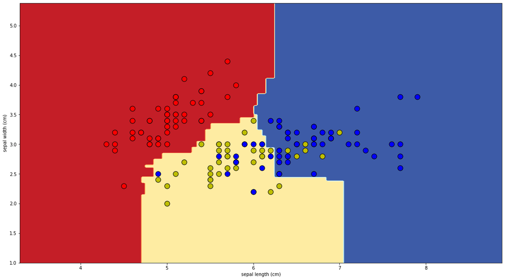

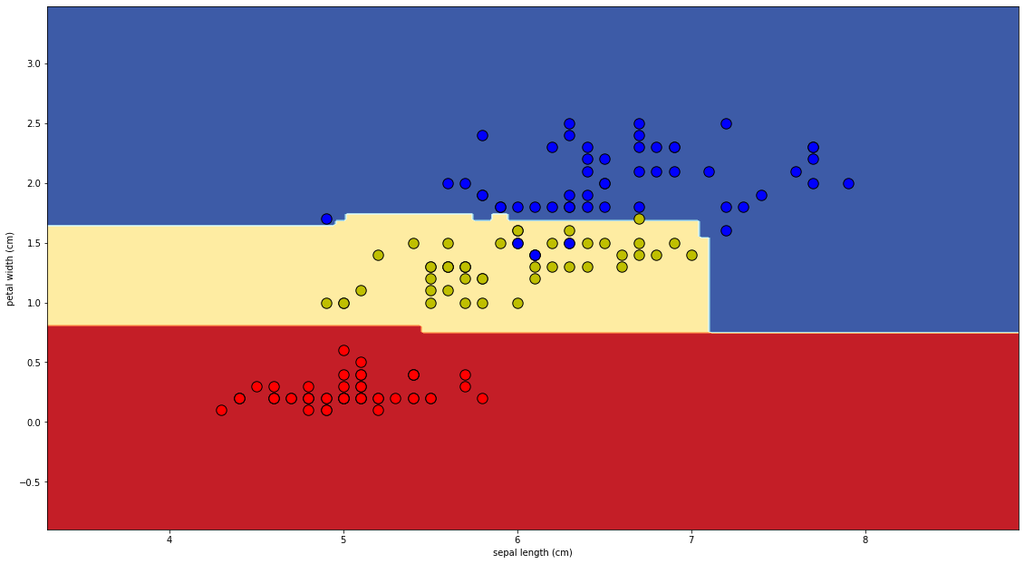

```python
iris = load_iris()
for pairidx, pair in enumerate([[0, 1],[0, 3]]):
    X = iris.data[:, pair]
    y = iris.target

    clf = RandomForestClassifier(max_depth=4, criterion="gini").fit(X, y)

    plt.figure(figsize=(16,9))
    plt.subplot()
    x_min, x_max = X[:, 0].min() - 1, X[:, 0].max() + 1
    y_min, y_max = X[:, 1].min() - 1, X[:, 1].max() + 1
    xx, yy = np.meshgrid(np.arange(x_min, x_max, 0.02),
                     np.arange(y_min, y_max, 0.02))
    plt.tight_layout(h_pad=0.5, w_pad=0.5, pad=2.5)

    Z = clf.predict(np.c_[xx.ravel(), yy.ravel()])
    Z = Z.reshape(xx.shape)

    cs = plt.contourf(xx, yy, Z, cmap=plt.cm.RdYlBu)
    plt.xlabel(iris.feature_names[pair[0]])
    plt.ylabel(iris.feature_names[pair[1]])

    for i, color in zip(range(3), "ryb"):
        idx = np.where(y == i)
        plt.scatter(X[idx, 0], X[idx, 1], c=color, label=iris.target_names[i],
                    cmap=plt.cm.RdYlBu, edgecolor='black', s=130)
```

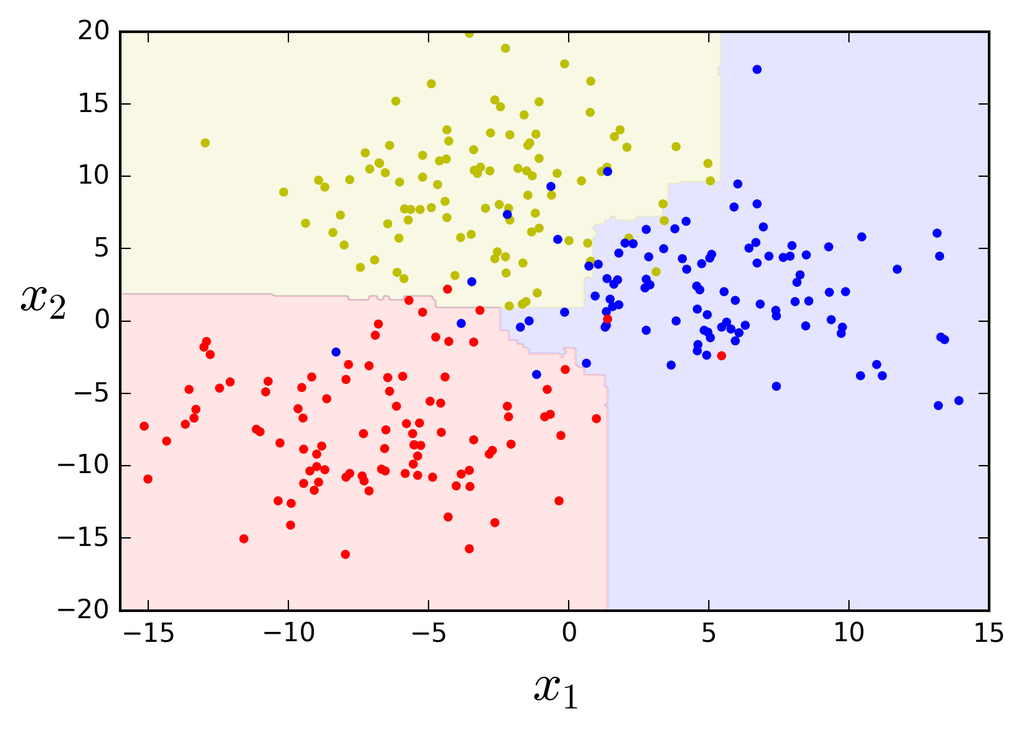

```python
Image(filename='10.png')
```

## Random Forest

maybe use (https://www.lpsm.paris/pageperso/has/source/Hand-on-ML.pdf, chapter 7)

- Describe random forest algorithm as a tree bagging method
- Talk about feature importance ??

```python
# random forest pseudocode
class RandomForest:
    def __init__(self,
                 max_depth=4,
                 each_tree_data=70,
                 tree_count=5,
                 criterion="gini"):
        self.trees = []
        for i in range(tree_count):
            self.trees.append(DecisionTree())

    def fit(self, X, y):
        for index, tree in enumerate(self.trees):
            # todo, use self.each_tree_data
            self.trees[index].fit(X_part, y_part)

    def predict(self, X):
        predictions = []
        for index, tree in enumerate(self.trees):
            predictions.append(self.tree[index].predict(X))
        # handle predictions
        return y
```

## Blending and stacking

- explain what are belnding and stacking

### Blending

Blending follows the same approach as stacking but uses only a validation set from the train set to make predictions. In other words, unlike stacking, the predictions are made on the validation set only. The validation set and the predictions are used to build a model which is run on the test set. Here is a detailed explanation of the blending process:

1. The train set is split into training and validation sets.

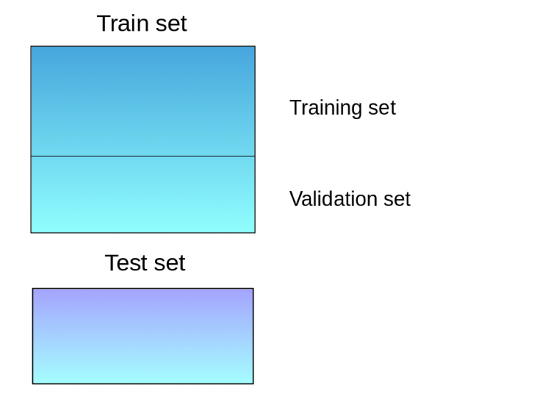

```python
Image(filename='image-7-768x579.png')
```

1. Model(s) are fitted on the training set.
2. The predictions are made on the validation set and the test set.

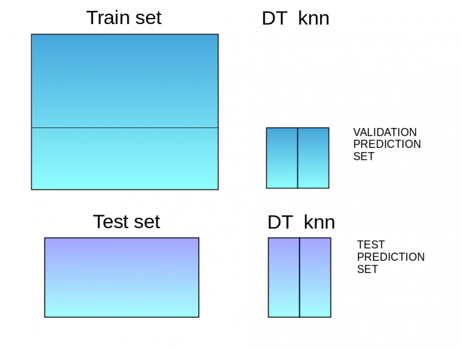

```python
Image(filename='image-5-768x582.png')
```

1. The validation set and its predictions are used as features to build a new model.
2. This model is used to make final predictions on the test and meta-features.

### Stacking

Stacking (sometimes called stacked generalization) involves training a learning algorithm to combine the predictions of several other learning algorithms. First, all of the other algorithms are trained using the available data, then a combiner algorithm is trained to make a final prediction using all the predictions of the other algorithms as additional inputs. If an arbitrary combiner algorithm is used, then stacking can theoretically represent any of the ensemble techniques described in this article, although, in practice, a logistic regression model is often used as the combiner.

1. The train set is split into 10 parts.

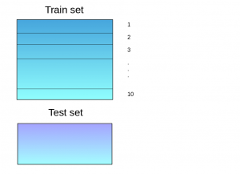

```python
Image(filename='image-11-300x217.png')
```

1. A base model (suppose a decision tree) is fitted on 9 parts and predictions are made for the 10th part. This is done for each part of the train set.

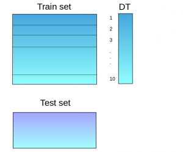

```python
Image(filename='image.png')
```

1. The base model (in this case, decision tree) is then fitted on the whole train dataset.
1. Using this model, predictions are made on the test set.

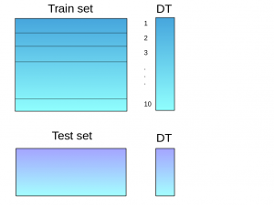

```python
Image(filename='image-2-300x225.png')
```

1. Steps 2 to 4 are repeated for another base model (say knn) resulting in another set of predictions for the train set and test set.

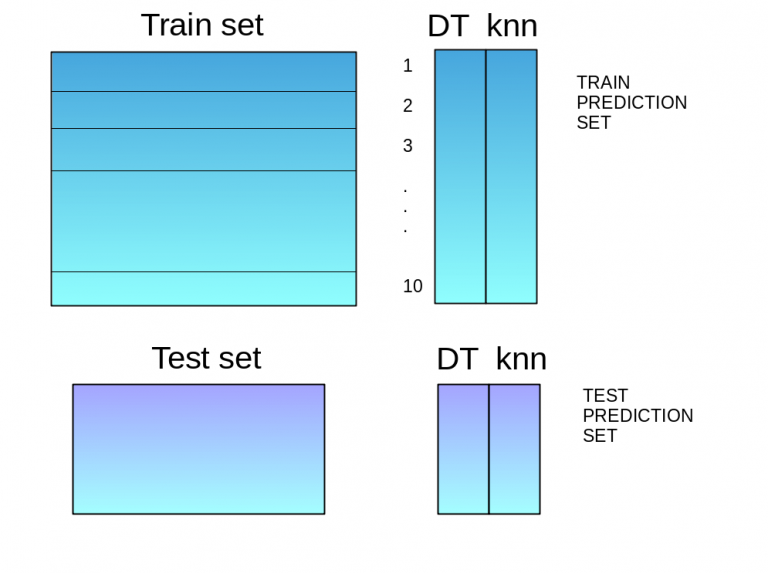

```python
Image(filename='image-3-768x573.png')
```

1. The predictions from the train set are used as features to build a new model.

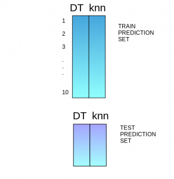

```python
Image(filename='image12-292x300.png')
```

1. This model is used to make final predictions on the test prediction set.

```python
# blending and stacking pseudocde
class blend:
    def __init__(self, models: list, model_params: list,
                 blender_model, blender_param: dict,
                 train_percent=80):
        self.models = []
        for index, model in enumerate(models):
            self.models.append(model(**model_params[index]))
        self.blender = blender_model(**blender_param)
        self.train_percent = train_percent

    def fit(self, X, y):
        #X_train, y_train, X_test, y_test use self.train_percent
        predictions = []
        for index, _ in enumerate(self.models):
            self.models[index].fit(X_train, y_train)
            predictions.append(self.models[index].predict(X_test))
        self.blender_model.fit(predictions, y_test)

    def predict(self, X):
        for index, _ in enumerate(self.models):
            predictions.append(self.models[index].predict(X))
        return self.blender_model.predict(predictions)

class stack:
    def __init__(self, folds,
                 models: list, model_params: list,
                 blender_model, blender_param: dict):
        self.blender = blender_model(**blender_param)
        self.folds = folds
        self.models = models
        self.model_params = model_params

    def fit(self, X, y):
        # todo folds
        all_predictions = []
        for fold in folds:
            # len(fold) = len(X)*(self.folds-1) / self.folds
            # len(out_of_fold) = len(X) / self.folds
            predictions = []
            models = [self.models[index](**self.model_params[index])
                      for index, _ in enumerate(self.models)]
            for index, _ in enumerate(models):
                models[index].fit(fold)
                predictions.append(models[index].predict(out_of_fold))
            all_predictions.append(predictions)
        # todo, all_predictions shape like y, len(all_predictions) = len(y)
        self.blender_model.fit(all_predictions, y)

    def predict(X):
        pass
```

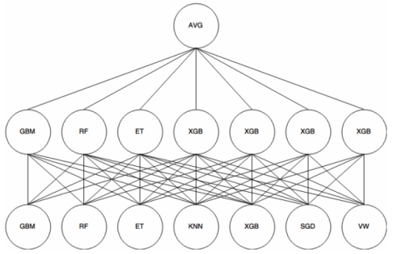

```python
Image(filename='11.png')
```